**Deep Learning for Mechanical Engineering**  
**Self-supervised Learning**

Instructor: Prof. Seungchul Lee  
http://iai.postech.ac.kr/  
Industrial AI Lab at POSTECH

# Problem 1. Pretext Tasks

(1) Prof. Lee has explained about various pretext tasks you can use for the self-supervised learning. Choose one pretext task and explain the mechanism of that pretext task for self-supervised learning in detail. (Exclude the Rotation Network)

(2) Draw the model (network) used in the pretext task chosen at (1) and explain in detail (Specify the function of each part of the model)

- You may use figures in articles

(3) Explain downstream tasks that the pretext task specified at (1) can be applied

Answer  
(1) Context Prediction is a pretext task that creates nine 3x3-shaped patches from an input image and then finds out the relative position of an arbitrary patch based on the patch located in the middle. In Context Prediction, the input is a center patch and one non-center patch, and the output is a value representing the relative position of the non-center patch from 1 to 8. Context Prediction is a type of Self-supervised Learning because a patch can be created from an input image and a label can be automatically generated even if a person does not directly create a label by selecting a random patch.

(2) Since the input of Context Prediction is two patches, there are two branches in the network that receive each of two patches. Two branches share the same weights and there is a final layer that aggregates the results of two branches and use them to make predictions.

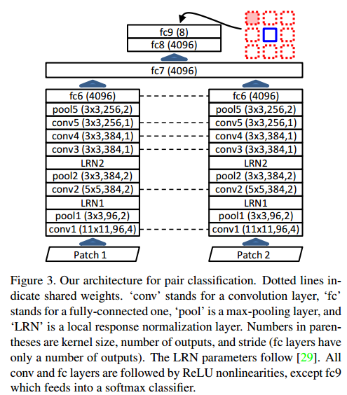

(3) The model trained through the pretext task described above can obtain features of images very well. After fixing the weights of the model, downstream tasks like classification can be performed based on the obtain features.

# Problem 2. Self-supervised Learning (RotNet) vs. Transfer Learning

- Self-supervised Learning (SSL) is very similar to Transfer Learning but they are different in the point that Self-supervised Learning uses unlabeled data but Transfer Learning requires labeled data
- In the real world, there are more unlabeled data than labeled ones.
- We are going to compare the performance between the Self-supervised Learning and Transfer Learning

```python
import tensorflow as tf
import numpy as np
import matplotlib.pyplot as plt
```

(1) Load dataset

- We will use Fashion MNIST dataset for the pretext (pretraining) task
- Mimicing the situation that there are more unlabeled data than labeled ones, we will use first 10000 Fashion MNIST dataset as input data for the Rotation Network.
- We will use next 300 Fashion MNIST dataset as input data for the Transfer Learning model.

```python
(X_train, Y_train), (X_test, Y_test) = tf.keras.datasets.fashion_mnist.load_data()

T_train = X_train[10000:10300]
T_train = T_train.reshape(-1, 28, 28, 1)
TY_train = Y_train[10000:10300]
TY_train = tf.one_hot(TY_train, 10, on_value = 1.0, off_value = 0.0)
X_train = X_train[:10000]
```

```python
print('Shape of RotNet Training:', X_train.shape)
print('Shape of Transfer Leaning Training:', T_train.shape)
print('Shape of Labels for Transfer Learning Training:', TY_train.shape)
```

```
Shape of RotNet Training: (10000, 28, 28)
Shape of Transfer Leaning Training: (300, 28, 28, 1)
Shape of Labels for Transfer Learning Training: (300, 10)
```

(2) Build dataset for the Rotation Network

```python
n_samples = X_train.shape[0]
X_rotate = np.zeros(shape = (n_samples * 4,
                             X_train.shape[1],
                             X_train.shape[2]))
Y_rotate = np.zeros(shape = (n_samples * 4, 4))

for i in range(n_samples):
    img = X_train[i]
    X_rotate[4 * i - 4] = img
    Y_rotate[4 * i - 4] = tf.one_hot([0], depth = 4)

    # 90 degrees rotation
    X_rotate[4 * i - 3] = np.rot90(img, k = 1)
    Y_rotate[4 * i - 3] = tf.one_hot([1], depth = 4)

    # 180 degrees rotation
    X_rotate[4 * i - 2] = np.rot90(img, k = 2)
    Y_rotate[4 * i - 2] = tf.one_hot([2], depth = 4)

    # 270 degrees rotation
    X_rotate[4 * i - 1] = np.rot90(img, k = 3)
    Y_rotate[4 * i - 1] = tf.one_hot([3], depth = 4)
```

(3) Plot dataset for the Rotation Network

```
(-0.5, 27.5, 27.5, -0.5)
```

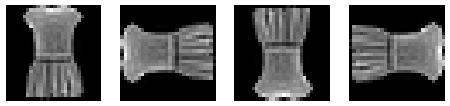

```python
plt.subplots(figsize = (10, 10))

plt.subplot(141)
plt.imshow(X_rotate[8], cmap = 'gray')
plt.axis('off')

plt.subplot(142)
plt.imshow(X_rotate[9], cmap = 'gray')
plt.axis('off')

plt.subplot(143)
plt.imshow(X_rotate[10], cmap = 'gray')
plt.axis('off')

plt.subplot(144)
plt.imshow(X_rotate[11], cmap = 'gray')
plt.axis('off')
```

```python
X_rotate = X_rotate.reshape(-1, 28, 28, 1)
```

(4) Build and train the Rotation Network

- You may use the same structure introduced during the class

```python
model_pretext = tf.keras.models.Sequential([
    tf.keras.layers.Conv2D(filters = 64,
                           kernel_size = (3, 3),
                           strides = (2, 2),
                           activation = 'relu',
                           padding = 'SAME',
                           input_shape = (28, 28, 1)),

    tf.keras.layers.MaxPool2D(pool_size = (2, 2),
                              strides = (2, 2)),

    tf.keras.layers.Conv2D(filters = 32,
                           kernel_size = (3, 3),
                           strides = (1, 1),
                           activation = 'relu',
                           padding = 'SAME',
                           input_shape = (7, 7, 64)),

    tf.keras.layers.MaxPool2D(pool_size = (2, 2),
                              strides = (2, 2)),

    tf.keras.layers.Conv2D(filters = 16,
                           kernel_size = (3, 3),
                           strides = (2, 2),
                           activation = 'relu',
                           padding = 'SAME',
                           input_shape = (3, 3, 32)),

    tf.keras.layers.Flatten(),

    tf.keras.layers.Dense(units = 4, activation = 'softmax')

])
model_pretext.summary()
```

```
Model: "sequential"
_________________________________________________________________
Layer (type)                 Output Shape              Param #
=================================================================
conv2d (Conv2D)              (None, 14, 14, 64)        640
_________________________________________________________________
max_pooling2d (MaxPooling2D) (None, 7, 7, 64)          0
_________________________________________________________________
conv2d_1 (Conv2D)            (None, 7, 7, 32)          18464
_________________________________________________________________
max_pooling2d_1 (MaxPooling2 (None, 3, 3, 32)          0
_________________________________________________________________
conv2d_2 (Conv2D)            (None, 2, 2, 16)          4624
_________________________________________________________________
flatten (Flatten)            (None, 64)                0
_________________________________________________________________
dense (Dense)                (None, 4)                 260
=================================================================
Total params: 23,988
Trainable params: 23,988
Non-trainable params: 0
_________________________________________________________________
```

```python
model_pretext.compile(optimizer = 'adam',
                      loss = 'categorical_crossentropy',
                      metrics = 'accuracy')

model_pretext.fit(X_rotate,
                  Y_rotate,
                  batch_size = 192,
                  epochs = 50,
                  verbose = 2,
                  shuffle = False)
```

```
209/209 - 5s - loss: 0.8397 - accuracy: 0.7729
209/209 - 4s - loss: 0.2455 - accuracy: 0.9191
209/209 - 4s - loss: 0.1787 - accuracy: 0.9424
209/209 - 5s - loss: 0.1446 - accuracy: 0.9532
209/209 - 5s - loss: 0.1251 - accuracy: 0.9598
209/209 - 5s - loss: 0.1101 - accuracy: 0.9649
209/209 - 5s - loss: 0.0972 - accuracy: 0.9681
209/209 - 5s - loss: 0.0870 - accuracy: 0.9710
209/209 - 5s - loss: 0.0764 - accuracy: 0.9746
209/209 - 5s - loss: 0.0715 - accuracy: 0.9765
209/209 - 5s - loss: 0.0670 - accuracy: 0.9771
209/209 - 5s - loss: 0.0597 - accuracy: 0.9801
209/209 - 5s - loss: 0.0533 - accuracy: 0.9821
209/209 - 5s - loss: 0.0575 - accuracy: 0.9801
209/209 - 5s - loss: 0.0479 - accuracy: 0.9840
209/209 - 5s - loss: 0.0487 - accuracy: 0.9825
209/209 - 5s - loss: 0.0455 - accuracy: 0.9838
209/209 - 5s - loss: 0.0448 - accuracy: 0.9838
209/209 - 5s - loss: 0.0425 - accuracy: 0.9848
209/209 - 5s - loss: 0.0408 - accuracy: 0.9856
209/209 - 5s - loss: 0.0409 - accuracy: 0.9860
209/209 - 5s - loss: 0.0375 - accuracy: 0.9870
209/209 - 5s - loss: 0.0372 - accuracy: 0.9866
209/209 - 5s - loss: 0.0346 - accuracy: 0.9877
209/209 - 5s - loss: 0.0302 - accuracy: 0.9894
209/209 - 5s - loss: 0.0330 - accuracy: 0.9882
209/209 - 5s - loss: 0.0337 - accuracy: 0.9889
209/209 - 5s - loss: 0.0307 - accuracy: 0.9890
209/209 - 5s - loss: 0.0308 - accuracy: 0.9886
209/209 - 5s - loss: 0.0319 - accuracy: 0.9890
209/209 - 5s - loss: 0.0264 - accuracy: 0.9908
209/209 - 5s - loss: 0.0249 - accuracy: 0.9916
209/209 - 5s - loss: 0.0234 - accuracy: 0.9914
209/209 - 5s - loss: 0.0264 - accuracy: 0.9911
209/209 - 5s - loss: 0.0198 - accuracy: 0.9933
209/209 - 5s - loss: 0.0193 - accuracy: 0.9932
209/209 - 5s - loss: 0.0257 - accuracy: 0.9905
209/209 - 5s - loss: 0.0316 - accuracy: 0.9895
209/209 - 5s - loss: 0.0218 - accuracy: 0.9925
209/209 - 5s - loss: 0.0236 - accuracy: 0.9919
209/209 - 5s - loss: 0.0207 - accuracy: 0.9926
209/209 - 5s - loss: 0.0184 - accuracy: 0.9934
209/209 - 5s - loss: 0.0208 - accuracy: 0.9925
209/209 - 6s - loss: 0.0201 - accuracy: 0.9933
209/209 - 5s - loss: 0.0199 - accuracy: 0.9929
209/209 - 5s - loss: 0.0210 - accuracy: 0.9927
209/209 - 5s - loss: 0.0165 - accuracy: 0.9941
209/209 - 4s - loss: 0.0208 - accuracy: 0.9929
209/209 - 5s - loss: 0.0171 - accuracy: 0.9938
209/209 - 5s - loss: 0.0217 - accuracy: 0.9928
```

```
<keras.callbacks.History at 0x1fad8a81be0>
```

(5) Fix the parameters of trained Rotation Network (Self-supervised Learning)

```python
model_pretext.trainable = False
```

(6) Build and train the Transfer Learning network

- Transfer Learning should have same structure with the Rotation Network
- Use same optimizer, epoch, loss, batch size ... etc. with that were used for training the Rotation Network
- This is supervised learning, so we will use ground truth labels for training

```python
model_transfer = tf.keras.models.Sequential([
    tf.keras.layers.Conv2D(filters = 64,
                           kernel_size = (3, 3),
                           strides = (2, 2),
                           activation = 'relu',
                           padding = 'SAME',
                           input_shape = (28, 28, 1)),

    tf.keras.layers.MaxPool2D(pool_size = (2, 2),
                              strides = (2, 2)),

    tf.keras.layers.Conv2D(filters = 32,
                           kernel_size = (3, 3),
                           strides = (1, 1),
                           activation = 'relu',
                           padding = 'SAME',
                           input_shape = (7, 7, 64)),

    tf.keras.layers.MaxPool2D(pool_size = (2, 2),
                              strides = (2, 2)),

    tf.keras.layers.Conv2D(filters = 16,
                           kernel_size = (3, 3),
                           strides = (2, 2),
                           activation = 'relu',
                           padding = 'SAME',
                           input_shape = (3, 3, 32)),

    tf.keras.layers.Flatten(),

    tf.keras.layers.Dense(units = 10, activation = 'softmax')

])
model_transfer.summary()
```

```
Model: "sequential_1"
_________________________________________________________________
Layer (type)                 Output Shape              Param #
=================================================================
conv2d_3 (Conv2D)            (None, 14, 14, 64)        640
_________________________________________________________________
max_pooling2d_2 (MaxPooling2 (None, 7, 7, 64)          0
_________________________________________________________________
conv2d_4 (Conv2D)            (None, 7, 7, 32)          18464
_________________________________________________________________
max_pooling2d_3 (MaxPooling2 (None, 3, 3, 32)          0
_________________________________________________________________
conv2d_5 (Conv2D)            (None, 2, 2, 16)          4624
_________________________________________________________________
flatten_1 (Flatten)          (None, 64)                0
_________________________________________________________________
dense_1 (Dense)              (None, 10)                650
=================================================================
Total params: 24,378
Trainable params: 24,378
Non-trainable params: 0
_________________________________________________________________
```

```python
model_transfer.compile(optimizer = 'adam',
                       loss = 'categorical_crossentropy',
                       metrics = 'accuracy')

model_transfer.fit(T_train,
                   TY_train,
                   batch_size = 192,
                   epochs = 50)
```

```
<keras.callbacks.History at 0x1fad8c76c50>
```

(7) Fix the parameters of trained network (Transfer Learning)

```python
model_transfer.trainable = False
```

(8) Define the training and test dataset for the downstream task

- We will use MNIST dataset for the downstream task

```python
(D_train, DY_train), (D_test, DY_test) = tf.keras.datasets.mnist.load_data()
D_train = D_train.reshape(-1, 28, 28, 1)
D_train = D_train[:300]
D_test = D_test.reshape(-1, 28, 28, 1)
D_test = D_test[:200]

DY_train = tf.one_hot(DY_train, 10, on_value = 1.0, off_value = 0.0)
DY_train = DY_train [0:300]
DY_test = tf.one_hot(DY_test, 10, on_value = 1.0, off_value = 0.0)
DY_test = DY_test [0:200]

print('Shape of Downstream Task Training:', D_train.shape)
print('Shape of Labels for Downstream Task Training:', DY_train.shape)
print('Shape of Downstream Task Test:', D_test.shape)
print('Shape of Labels for Downstream Task Test:', DY_test.shape)
```

```
Shape of Downstream Task Training: (300, 28, 28, 1)
Shape of Labels for Downstream Task Training: (300, 10)
Shape of Downstream Task Test: (200, 28, 28, 1)
Shape of Labels for Downstream Task Test: (200, 10)
```

(9) Build the Downstream Network that uses pretrained parameters of Rotation Network

- Follow the model summary to build the network (First four layers' parameters are not trainable)

```python
model_downstream = tf.keras.models.Sequential([
    model_pretext.get_layer(index = 0),
    model_pretext.get_layer(index = 1),
    model_pretext.get_layer(index = 2),
    model_pretext.get_layer(index = 3),

    tf.keras.layers.Flatten(),
    tf.keras.layers.Dense(units = 10, activation = 'softmax')
])

model_downstream.summary()
```

```
Model: "sequential_2"
_________________________________________________________________
Layer (type)                 Output Shape              Param #
=================================================================
conv2d (Conv2D)              (None, 14, 14, 64)        640
_________________________________________________________________
max_pooling2d (MaxPooling2D) (None, 7, 7, 64)          0
_________________________________________________________________
conv2d_1 (Conv2D)            (None, 7, 7, 32)          18464
_________________________________________________________________
max_pooling2d_1 (MaxPooling2 (None, 3, 3, 32)          0
_________________________________________________________________
flatten_2 (Flatten)          (None, 288)               0
_________________________________________________________________
dense_2 (Dense)              (None, 10)                2890
=================================================================
Total params: 21,994
Trainable params: 2,890
Non-trainable params: 19,104
_________________________________________________________________
```

```python
model_downstream.compile(optimizer = tf.keras.optimizers.SGD(learning_rate = 0.001, momentum = 0.9),
                         loss = 'categorical_crossentropy',
                         metrics = 'accuracy')

model_downstream.fit(D_train,
                     DY_train,
                     batch_size = 64,
                     validation_split = 0.2,
                     epochs = 50,
                     verbose = 2,
                     callbacks = tf.keras.callbacks.EarlyStopping(monitor = 'accuracy', patience = 7))
```

```
4/4 - 0s - loss: 75.5730 - accuracy: 0.1625 - val_loss: 60.5109 - val_accuracy: 0.2667
4/4 - 0s - loss: 55.6027 - accuracy: 0.3833 - val_loss: 31.8886 - val_accuracy: 0.4833
4/4 - 0s - loss: 25.4360 - accuracy: 0.5500 - val_loss: 36.1484 - val_accuracy: 0.5833
4/4 - 0s - loss: 21.2653 - accuracy: 0.7083 - val_loss: 17.9549 - val_accuracy: 0.6833
4/4 - 0s - loss: 8.4240 - accuracy: 0.8000 - val_loss: 14.7263 - val_accuracy: 0.7000
4/4 - 0s - loss: 8.0828 - accuracy: 0.8375 - val_loss: 17.4232 - val_accuracy: 0.7833
4/4 - 0s - loss: 4.1006 - accuracy: 0.9083 - val_loss: 13.9359 - val_accuracy: 0.7333
4/4 - 0s - loss: 2.9852 - accuracy: 0.9125 - val_loss: 5.3910 - val_accuracy: 0.8500
4/4 - 0s - loss: 1.3471 - accuracy: 0.9583 - val_loss: 6.4210 - val_accuracy: 0.8333
4/4 - 0s - loss: 1.4154 - accuracy: 0.9625 - val_loss: 6.8997 - val_accuracy: 0.8167
4/4 - 0s - loss: 0.5660 - accuracy: 0.9583 - val_loss: 6.5693 - val_accuracy: 0.8167
4/4 - 0s - loss: 0.1708 - accuracy: 0.9833 - val_loss: 8.8576 - val_accuracy: 0.7833
4/4 - 0s - loss: 0.4264 - accuracy: 0.9833 - val_loss: 9.6623 - val_accuracy: 0.7667
4/4 - 0s - loss: 0.2859 - accuracy: 0.9792 - val_loss: 7.4502 - val_accuracy: 0.8333
4/4 - 0s - loss: 0.0154 - accuracy: 0.9958 - val_loss: 7.1444 - val_accuracy: 0.8333
4/4 - 0s - loss: 0.0067 - accuracy: 0.9958 - val_loss: 7.2684 - val_accuracy: 0.8333
4/4 - 0s - loss: 5.0366e-05 - accuracy: 1.0000 - val_loss: 7.7123 - val_accuracy: 0.8167
4/4 - 0s - loss: 0.0430 - accuracy: 0.9958 - val_loss: 7.7334 - val_accuracy: 0.8333
4/4 - 0s - loss: 0.0021 - accuracy: 1.0000 - val_loss: 7.3814 - val_accuracy: 0.8167
4/4 - 0s - loss: 1.1905e-06 - accuracy: 1.0000 - val_loss: 7.1635 - val_accuracy: 0.8333
4/4 - 0s - loss: 1.2496e-06 - accuracy: 1.0000 - val_loss: 7.0408 - val_accuracy: 0.8333
4/4 - 0s - loss: 6.7578e-06 - accuracy: 1.0000 - val_loss: 6.9634 - val_accuracy: 0.8333
4/4 - 0s - loss: 2.7417e-05 - accuracy: 1.0000 - val_loss: 6.9135 - val_accuracy: 0.8333
4/4 - 0s - loss: 1.1928e-04 - accuracy: 1.0000 - val_loss: 6.8826 - val_accuracy: 0.8333
```

```
<keras.callbacks.History at 0x1fad9543d30>
```

(10) Build the Downstream Network that uses pretrained parameters of Transfer Learning

- Follow the model summary to build the network (First four layers' parameters are not trainable)
- You must build a network that has the same structure with that used in step (9)
- Use same number of epochs, optimizer, batch size, validation split, callbacks, .... etc with that were used in step (9)

```python
model_transferdownstream = tf.keras.models.Sequential([
    model_transfer.get_layer(index = 0),
    model_transfer.get_layer(index = 1),
    model_transfer.get_layer(index = 2),
    model_transfer.get_layer(index = 3),

    tf.keras.layers.Flatten(),
    tf.keras.layers.Dense(units = 10, activation = 'softmax')
])

model_transferdownstream.summary()
```

```
Model: "sequential_3"
_________________________________________________________________
Layer (type)                 Output Shape              Param #
=================================================================
conv2d_3 (Conv2D)            (None, 14, 14, 64)        640
_________________________________________________________________
max_pooling2d_2 (MaxPooling2 (None, 7, 7, 64)          0
_________________________________________________________________
conv2d_4 (Conv2D)            (None, 7, 7, 32)          18464
_________________________________________________________________
max_pooling2d_3 (MaxPooling2 (None, 3, 3, 32)          0
_________________________________________________________________
flatten_3 (Flatten)          (None, 288)               0
_________________________________________________________________
dense_3 (Dense)              (None, 10)                2890
=================================================================
Total params: 21,994
Trainable params: 2,890
Non-trainable params: 19,104
_________________________________________________________________
```

```python
model_transferdownstream.compile(optimizer = tf.keras.optimizers.SGD(learning_rate = 0.001, momentum = 0.9),
                                 loss = 'categorical_crossentropy',
                                 metrics = 'accuracy')

model_transferdownstream.fit(D_train,
                             DY_train,
                             batch_size = 64,
                             validation_split = 0.2,
                             epochs = 50,
                             verbose = 2,
                             callbacks = tf.keras.callbacks.EarlyStopping(monitor = 'accuracy', patience = 7))
```

```
4/4 - 0s - loss: 31.8436 - accuracy: 0.1083 - val_loss: 29.9029 - val_accuracy: 0.1667
4/4 - 0s - loss: 26.5366 - accuracy: 0.2333 - val_loss: 25.5985 - val_accuracy: 0.2167
4/4 - 0s - loss: 27.0512 - accuracy: 0.2667 - val_loss: 13.1689 - val_accuracy: 0.2833
4/4 - 0s - loss: 19.9853 - accuracy: 0.3375 - val_loss: 16.7455 - val_accuracy: 0.3333
4/4 - 0s - loss: 10.5987 - accuracy: 0.5375 - val_loss: 6.3729 - val_accuracy: 0.5667
4/4 - 0s - loss: 5.8901 - accuracy: 0.6417 - val_loss: 3.5604 - val_accuracy: 0.7167
4/4 - 0s - loss: 4.6811 - accuracy: 0.7542 - val_loss: 3.7026 - val_accuracy: 0.7833
4/4 - 0s - loss: 3.3352 - accuracy: 0.8042 - val_loss: 7.3355 - val_accuracy: 0.6500
4/4 - 0s - loss: 3.4521 - accuracy: 0.8042 - val_loss: 4.3794 - val_accuracy: 0.7333
4/4 - 0s - loss: 2.0893 - accuracy: 0.8625 - val_loss: 5.2374 - val_accuracy: 0.7500
4/4 - 0s - loss: 2.2527 - accuracy: 0.8792 - val_loss: 3.2944 - val_accuracy: 0.7000
4/4 - 0s - loss: 1.6466 - accuracy: 0.9083 - val_loss: 2.8039 - val_accuracy: 0.7000
4/4 - 0s - loss: 1.3384 - accuracy: 0.8958 - val_loss: 3.7177 - val_accuracy: 0.7500
4/4 - 0s - loss: 1.0848 - accuracy: 0.9208 - val_loss: 3.3879 - val_accuracy: 0.7833
4/4 - 0s - loss: 1.0279 - accuracy: 0.9375 - val_loss: 3.5137 - val_accuracy: 0.7667
4/4 - 0s - loss: 0.8777 - accuracy: 0.9625 - val_loss: 3.4507 - val_accuracy: 0.7167
4/4 - 0s - loss: 0.7003 - accuracy: 0.9625 - val_loss: 4.7914 - val_accuracy: 0.7167
4/4 - 0s - loss: 0.6144 - accuracy: 0.9583 - val_loss: 3.4893 - val_accuracy: 0.7333
4/4 - 0s - loss: 0.5135 - accuracy: 0.9708 - val_loss: 2.7371 - val_accuracy: 0.7667
4/4 - 0s - loss: 0.4502 - accuracy: 0.9708 - val_loss: 2.9428 - val_accuracy: 0.7333
4/4 - 0s - loss: 0.3596 - accuracy: 0.9708 - val_loss: 4.4478 - val_accuracy: 0.7000
4/4 - 0s - loss: 0.3249 - accuracy: 0.9667 - val_loss: 3.5839 - val_accuracy: 0.7333
4/4 - 0s - loss: 0.2626 - accuracy: 0.9792 - val_loss: 2.4936 - val_accuracy: 0.7833
4/4 - 0s - loss: 0.2159 - accuracy: 0.9792 - val_loss: 2.5563 - val_accuracy: 0.8000
4/4 - 0s - loss: 0.1686 - accuracy: 0.9917 - val_loss: 2.7654 - val_accuracy: 0.7667
4/4 - 0s - loss: 0.1516 - accuracy: 0.9875 - val_loss: 2.5146 - val_accuracy: 0.7833
4/4 - 0s - loss: 0.1112 - accuracy: 0.9875 - val_loss: 2.6082 - val_accuracy: 0.7833
4/4 - 0s - loss: 0.1800 - accuracy: 0.9750 - val_loss: 3.3133 - val_accuracy: 0.7500
4/4 - 0s - loss: 0.1305 - accuracy: 0.9875 - val_loss: 3.6891 - val_accuracy: 0.7000
4/4 - 0s - loss: 0.1034 - accuracy: 0.9708 - val_loss: 3.5800 - val_accuracy: 0.6833
4/4 - 0s - loss: 0.0749 - accuracy: 0.9833 - val_loss: 3.7319 - val_accuracy: 0.7167
4/4 - 0s - loss: 0.0486 - accuracy: 0.9750 - val_loss: 3.3913 - val_accuracy: 0.7333
```

```
<keras.callbacks.History at 0x1fad9604d68>
```

(11) Evaluate models trained in step (9) and step (10) with the same test dataset

```python
test_self = model_downstream.evaluate(D_test, DY_test, batch_size = 64, verbose = 2)

print("")
print('Self-supervised Learning Accuracy on Test Data:  {:.2f}%'.format(test_self[1] * 100))
```

```
4/4 - 0s - loss: 8.2355 - accuracy: 0.8250

Self-supervised Learning Accuracy on Test Data:  82.50%
```

```python
test_self = model_transferdownstream.evaluate(D_test, DY_test, batch_size = 64, verbose = 2)

print("")
print('Transfer Learning Accuracy on Test Data:  {:.2f}%'.format(test_self[1] * 100))
```

```
4/4 - 0s - loss: 3.7318 - accuracy: 0.7150

Transfer Learning Accuracy on Test Data:  71.50%
```